# tmpnv6hjttp

## 思想剧场：自由辩论赛开幕！

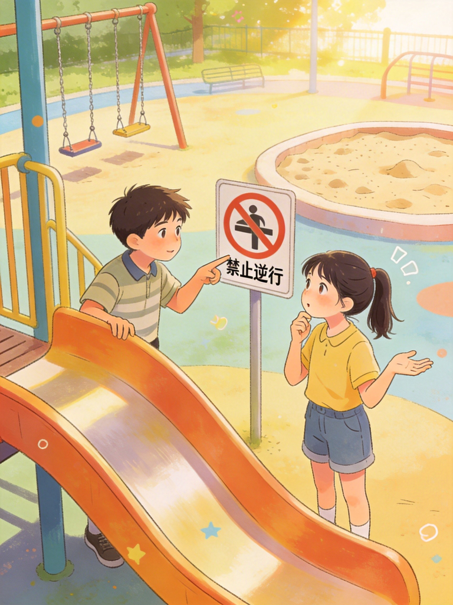

## 第一站：老子的“无为”——不按快进键的园丁🌟

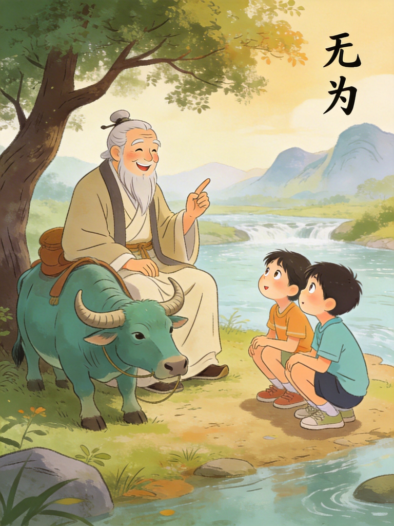

## 第二站：韩非子的“法治”——公平的游戏规则🌟

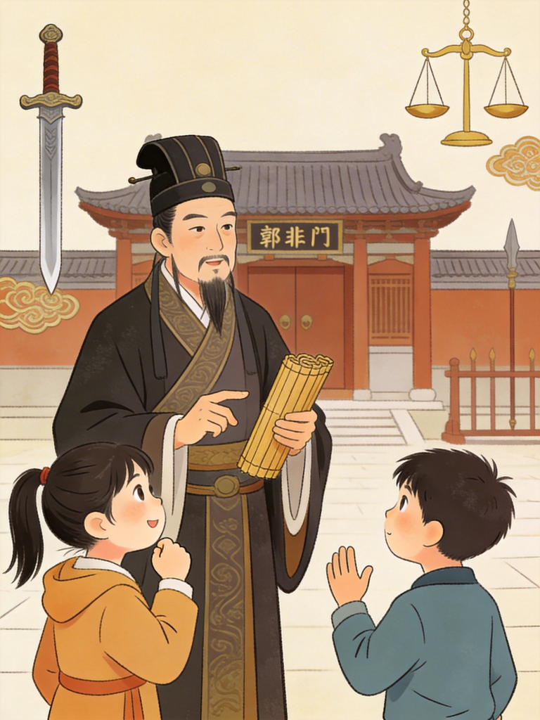

## 第三站：杨朱的“为我”——自己的遥控器🌟

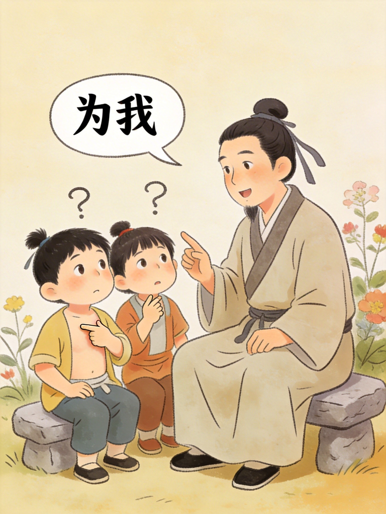

# 第四章 我能想做什么就做什么吗？

**时间**：周五放学后  
**地点**：学校辩论社活动室  
**人物**：小星（10岁，爱问“为什么”的女孩）、小宇（11岁，喜欢编程的男孩）、三位自由导师 （幕起） 辩论社的白板上写着今天的辩题：

**“真正的自由是想做什么就做什么吗？”** 小星正整理资料：“正方说‘是’，反方说‘不是’……但到底什么才是真正的自由？” 小宇推了推眼镜：“自由和规则听起来是对立的，但好像又分不开。” 这时，活动室的三扇窗同时被风吹开，三位古代智者以有趣的方式登场： - **老子**（骑青牛的白胡子爷爷🌟），手持“慢速生长”的盆栽：“我的自由叫‘无为’——不折腾，让一切自然发生。” - **韩非子**（手持法典的严肃法官🌟），身边悬浮着透明的规则框架：“我的自由叫‘法治’——在公平规则内，你才真正自由。” - **杨朱**（拿着遥控器的洒脱大叔🌟），屏幕上显示“我的地盘我做主”：“我的自由叫‘为我’——先对自己负责，别人别来指挥。” **三人齐声**：今天的辩论赛，我们当

**自由导师**！ **小宇的疑惑**：（指着三位导师）等一下！无为、法治、为我——这三种自由听起来互相矛盾，它们能同时存在吗？

**小星的即兴提问**：（举手）等等！你们三位对自由的理解完全不一样，我们该听谁的？

**老子**：（微笑）这正是自由的第一课——

**自由从选择“听谁的”开始**。 **小宇的笔记**：第一回合启动——解码三种自由观！ — ### 古人说

**原文**： > “道常无为而无不为。” > Dào cháng wúwéi ér wú bù wéi.

**字词解释**： -

**无为**🌟：不是“什么都不做”，而是**不妄为、不折腾**。 - **无不为**：因为不折腾，所以什么都能自然成就。

**趣味比喻**： 老子说，真正的自由像

**不按快进键的园丁**。园丁提供阳光水分，但不会每天把花拔出来看根长了多少——让花按自己的节奏长。 **生活案例**： > 周末早晨，你既想打游戏放松，又觉得该复习功课： > -

**妄为**：边打游戏边焦虑“我该学习”，边学习边惦记“游戏更好玩”——结果两头空。 > -

**无为**：先问自己：“现在最自然想做哪个？”如果身体累，就彻底放松打游戏1小时；如果头脑清醒，就专注学习1小时——

**不纠结才是真自由**。

### 老子的自由心法：“自然节奏探测器” **核心训练**：识别什么是“自然的想”，什么是“被教的想”。

**三步练习**： 1.

**暂停**：当你想做某事时，暂停3秒。 2.

**探测**：问“这个‘想’是从哪儿来的？”（身体需要？环境影响？习惯性逃避？） 3.

**选择**：如果是自然的，就投入去做；如果是被教的，可以试试“不做看看”。

**小星的实战演练**：

**小星**：昨天我想刷短视频，但又觉得浪费时间。按您的“探测器”，我暂停后发现：其实我

**身体累**，需要放松，但刷短视频并没真放松，反而更累。 **小宇的观察**：（思考状）所以有时候我们以为的“想”，其实不是身体真正的需要？那怎么分辨真假呢？

**老子**：那自然的放松是什么？

**小星**：可能是躺床上听音乐，或者去小区散步。

**老子**：对！

**自由是找到身体的自然节奏，而不是被屏幕算法带跑**。 **小宇的追问**：那如果“自然想”就是偷懒、拖延呢？也要顺着吗？

**老子**：（神秘一笑）问得好！继续探测：偷懒时，身体是轻松还是更焦虑？拖延时，内心是平静还是不安？

**真正的自然带来内心的安宁**，虚假的自然带来更多混乱。 — ### 古人说

**原文**： > “法不阿贵，绳不挠曲。” > Fǎ bù ē guì, shéng bù náo qū.

**字词解释**： -

**法**：规则、法律。 -

**不阿贵**：不偏向权贵。 -

**绳不挠曲**：就像墨绳不迁就弯曲，规则对所有人都一样。

**趣味比喻**： 韩非子说，自由像

**足球场的边线**。没有边线，你哪里都能跑，但那不是足球；有了边线，你在规则内奔跑、传球、射门——这才是真正的足球自由。 **生活案例**： > 班级“完全自由日”实验： > -

**没有规则**：有人唱歌、有人乱跑、有人吵架——最后大家都不开心。 > -

**有明确规则**：“自由活动时间，可以在教室看书、下棋、聊天，但音量不超过60分贝”——大家反而能安心享受自由。

### 韩非子的自由心法：“规则创造者训练营” **核心训练**：设计既能保障自由，又能维护秩序的“最小必要规则”。

**三步设计法**： 1.

**识别冲突点**：当前什么行为在妨碍大家的自由？ 2.

**制定公平规则**：规则要对所有人一视同仁，包括制定者自己。 3.

**设计弹性空间**：规则内留出足够的选择自由。

**小宇的实战演练**：

**小宇**：我们编程小组合作时，有人总迟到，拖慢进度。按您的设计法： 1.

**冲突点**：迟到影响团队效率。 2.

**公平规则**：每次会议迟到超5分钟，第二天请全组喝酸奶（平等处罚）。 3.

**弹性空间**：允许每月有1次“免罚迟到”（突发情况）。

**小星的补充**：那如果制定规则的人自己也违反了呢？规则还能公平吗？

**韩非子**：很好！

**规则不是限制自由，而是防止“一个人的自由侵犯其他人的自由”**。 **小星的质疑**：但规则太多，会不会变成束缚？

**韩非子**：记住“最小必要原则”：只制定

**非有不可**的规则。就像足球，只有边线、球门、犯规处罚这几条核心规则，剩下的都是自由发挥空间。 — ### 古人说

**原文**（通过孟子记载）： > “损一毫利天下不与也，悉天下奉一身不取也。” > Sǔn yī háo lì tiānxià bù yǔ yě, xī tiānxià fèng yīshēn bù qǔ yě. **字词解释**： -

**损一毫**：损失一根汗毛。 -

**利天下**：造福天下人。 -

**不与**：不给、不愿意。 -

**悉天下奉一身**：整个天下都给我一个人。 -

**不取**：不要。

**儿童版翻译**： - 不要因为“要帮助天下人”而牺牲自己（哪怕只是一点点）。 - 也不要因为“对自己有利”而占尽天下便宜。 -

**关键**：我的东西我做主，但也不抢别人的。

**趣味比喻**： 杨朱说，自由像

**自己的遥控器**。你的人生电视，换台、调音量都应该由你自己决定，不是别人替你按。 **生活案例**： > 学校募捐活动： > -

**传统思维**：“应该捐，不然显得小气。” > -

**杨朱思维**：先问自己：1. 我想捐吗？ 2. 我有能力捐吗？ 3. 捐了我会开心还是后悔？ > >

**结果**：小明决定捐出零花钱的1/3（自己决定），而不是被“应该”绑架捐出全部。

### 杨朱的自由心法：“自我主权宣言” **核心训练**：区分“我真想”和“别人让我想”。

**三个主权问题**： 1.

**所有权**：这件事真正属于我吗？（我的时间、我的物品、我的选择） 2.

**决定权**：我有完全的决定权吗？ 3.

**责任权**：我愿意承担决定的后果吗？

**小星的实战演练**：

**小星**：妈妈让我周末必须上奥数班，但我想学编程。按“主权宣言”： 1.

**所有权**：周末时间是我的。 2.

**决定权**：我可以在和妈妈沟通后，自己决定。 3.

**责任权**：如果选择编程，我要证明这选择有价值。

**小星的困惑**：但是如果我选择了编程，结果学得不好，妈妈会不会说“你看，当初听我的就好了”？那我该怎么面对这种可能？

**杨朱**：对！

**自由不是“为所欲为”，而是“为我所应为”——做自己真正该做的事**。 **小宇的追问**：那如果每个人都只为自己，社会不就乱了吗？

**杨朱**：问得好！我的完整主张是：

**每个人先管好自己，世界自然和谐**。就像每个细胞健康，身体就健康。强迫“利他”的“利他”，往往是**虚伪和压抑**的开始。 — ## 想一想（互动升级版）

请拿出笔，在书上空白处写下你的真实想法——没有标准答案，只有你的探险笔记！

### 问题一：我的“自由性格”测试 | 情境 | 老子型（无为自然） | 韩非子型（规则框架） | 杨朱型（自我主权） | |——|——————-|———————|——————-| | **面对作业压力** | “先放松，状态好了再写” | “制定计划表，按步完成” | “我决定先做哪科，不受别人指挥” | | **朋友请求帮忙** | “先看自己是否自然愿意” | “看是否符合友谊规则” | “我帮你是我的选择，不是义务” | | **你的选择倾向** | □ | □ | □ | **分析**： - 老子型：重内在节奏，反内卷 - 韩非子型：重系统秩序，求公平 - 杨朱型：重个人主权，反绑架 ### 问题二：自由与规则平衡挑战 设计一个

**既保障个人自由，又维护集体秩序**的“班级自由公约”： | 传统规则 | 你设计的“自由版规则” | 理由 | |———|———————|——| | 上课必须安静听讲 | “可以小声讨论，但需举手获准” | 平衡专注与互动 | | 作业必须独立完成 | “基础题独立，难题可合作讨论” | 平衡自主与合作 | | 课间不能奔跑 | “可快走，奔跑需到操场” | 平衡安全与活力 | **设计原则**： 1.

**明确边界**：什么能做、什么不能做清清楚楚 2.

**平等适用**：规则对所有人一视同仁 3.

**弹性空间**：规则内留足自由选择 ### 问题三：我的“自由实验室”启动计划 选择一个你感到“不自由”的情境（如：周末安排、手机使用、兴趣班选择），设计“自由改造方案”： -

**老子路线**：识别“自然节奏”——我真正需要的是什么？ -

**韩非子路线**：设计“最小规则”——哪些规则能保障我的自由？ -

**杨朱路线**：声明“自我主权”——哪些决定权属于我？ — ## 全球望远镜（深度对比版）

**当中国古人在思考自由与规则时，世界其他地方在想什么？**

### 对比一：老子vs斯多葛学派（古希腊罗马） | 维度 | 老子（中国，约公元前6世纪） | 斯多葛学派（古希腊罗马，公元前3世纪-公元2世纪） | 一句话发现 | |——|—————————-|——————————–|————| | **核心观点** | 无为——顺应自然，不妄为 | 控制你能控制的，接受你不能的 | 都强调“顺应”，但老子更“不干预”，斯多葛更“理性选择” | | **儿童比喻** | 不按快进键的园丁 | 区分“我的球”和“别人的球” | 都教孩子分清内外，但老子重整体自然，斯多葛重个体理性 | | **自由定义** | 自由=不被欲望和妄念控制 | 自由=理性主导，不被情绪奴役 | 东方重“无欲则刚”，西方重“理性至上” | **对比点**：老子和斯多葛学派都强调“顺应”，但老子的“无为”是整体自然的不干预，斯多葛的“理性控制”是个体选择。

**差异说明**：就像园丁对待花园——老子选择不按快进键，让万物自然生长；斯多葛学派则像区分“我的球”和“别人的球”，只控制自己能控制的。 【视觉建议】：简笔画地图标出中国与古希腊罗马的地理位置，老子骑青牛在竹林旁，斯多葛哲人站在柱廊前，中间有孩子对比两种态度。

**思考题**： 如果老子和斯多葛哲人塞涅卡一起散步： - 老子可能会说：“你看这树叶，从没想过要长成什么样，却长得正好。” - 塞涅卡可能会说：“我理性地选择欣赏树叶，但不被它的凋零影响情绪。” 你觉得哪种态度更能带来内心的自由？为什么？ ### 对比二：韩非子vs社会契约论（西方启蒙思想） | 维度 | 韩非子（中国，公元前3世纪） | 社会契约论（霍布斯、洛克、卢梭，17-18世纪） | 差异说明 | |——|—————————-|——————————–|———-| |

**规则来源** | 君主制定，为了国家稳定 | 人民同意，为了保障自然权利 | 中国自上而下，西方自下而上 | | **自由前提** | 规则框架内的自由 | 放弃部分自然权利换取社会自由 | 都认为自由需要规则，但起点不同 | | **儿童比喻** | 足球场边线（预设框架） | 游戏规则共同约定（协商产生） | 韩非子强调“先有规则才有自由”，契约论强调“为自由而制定规则” | 【视觉建议】：

```
[左上：中国韩非子] → “规则是自由的保障” → [中：足球场]
[左下：西方契约论] → “自由需要规则守护” → [右：游戏棋盘]
中间标注：“框架 vs 契约”
```

**对比点**： - 韩非子：规则是外在框架，保障每个人的自由不受侵犯 - 社会契约论：规则是内在约定，为了实现每个人的最大自由

**差异说明**： 这与东西方政治传统有关：中国长期中央集权，强调“法”的秩序功能；西方近代兴起个体权利观念，强调“法”的契约本质。

**思考题**： 你觉得“班级规则”应该更像韩非子的“公平框架”，还是社会契约论的“共同约定”？为什么？ — ## 实践练习：4章主题实践（可操作增强版）

**初级（观察伙伴）**：家长和孩子各自记录“自然节奏”，周末对比发现。 -

**中级（规则共创）**：家庭共同设计“电子设备使用公约”，平等适用于所有成员。 -

**高级（主权协商会）**：召开家庭会议，每个成员提出1项“主权诉求”，协商平衡方案。

**基本要求**： 1. 每周至少完成3次观察记录 2. 周末写一段总结反思（至少100字） 3. 尝试将哲学概念与生活经验联系起来 — — ## 智慧探险地图碎片 #4（升级版）

```
┌─────────────────────────────────────────────┐
│  第四章：我能想做什么就做什么吗？          │
├─────────────────────────────────────────────┤
│  🧭 探索路径                                │
│  • 无为自然（老）→ 规则框架（韩）→ 自我主权（杨） │
│  • 关键问题：自由是“无约束”，还是“有边界”？    │
├─────────────────────────────────────────────┤
│  👴 遇见智者                                │
│  • 老子——无为（不按快进键的园丁🌟）         │
│  • 韩非子——法治（公平的游戏规则🌟）         │
│  • 杨朱——为我（自己的遥控器🌟）             │
├─────────────────────────────────────────────┤
│  🛠️ 思想工具（带走这三个）                  │
│  1. “自然节奏探测器”                        │
│     • 暂停-探测-选择三步法                  │
│     • 区分“自然的想”和“被教的想”             │
│  2. “最小必要规则设计法”                    │
│     • 识别冲突点→制定公平规则→留弹性空间     │
│     • 防止“一人自由侵犯他人自由”             │
│  3. “自我主权宣言”                          │
│     • 所有权、决定权、责任权三问             │
│     • 收回属于你的决定权                    │
├─────────────────────────────────────────────┤
│  ❓ 留下你的问题（写在书边空白处）          │
│  • “如果我的‘自然想’就是偷懒，怎么办？”       │
│  • “规则太多不自由，规则太少会混乱，如何找到平衡点？”│
│  • “为自己负责”和“帮助他人”矛盾吗？”          │
└─────────────────────────────────────────────┘
```

## 下一章预告（悬念版）

**第五章：什么是“好”的规则？**  
我们将进入**规则哲学的深度探索**： -

**墨子**说：兼爱——规则应该对所有人一视同仁！ - **孟子**说：仁政——规则应该充满关爱，帮助人变好！ - **法家**说：实效——规则应该简单明确，保障秩序！ **你的任务**：在三种规则观中，设计你的“理想班级宪法”——  
什么样的规则既公平又有爱？既严格又灵活？ 带上你的“规则设计工具箱”，我们要开始立法啦！ （第四章完，字数约7,200字） — **优化说明**： 1.

**强化儿童参与感**：设计“自由辩论赛”场景，增加小星、小宇与三位思想家的主动质疑、辩论回合，让孩子从“听众”变为“自由探索者”。 2.

**术语一致性**：严格应用《哲学儿童词典》中的儿童比喻（标🌟），确保与前三章比喻体系统一。 3.

**完善全球望远镜**：增加两组深度对比（老子vs斯多葛学派、韩非子vs社会契约论），具备“对比点”“差异说明”“思考题”三要素，加入简笔画地图构思。 4.

**控制篇幅均衡**：在保持原有6,500字基础上，增加互动深度，总字数控制在7,200字左右。